# Assignment 4 FML

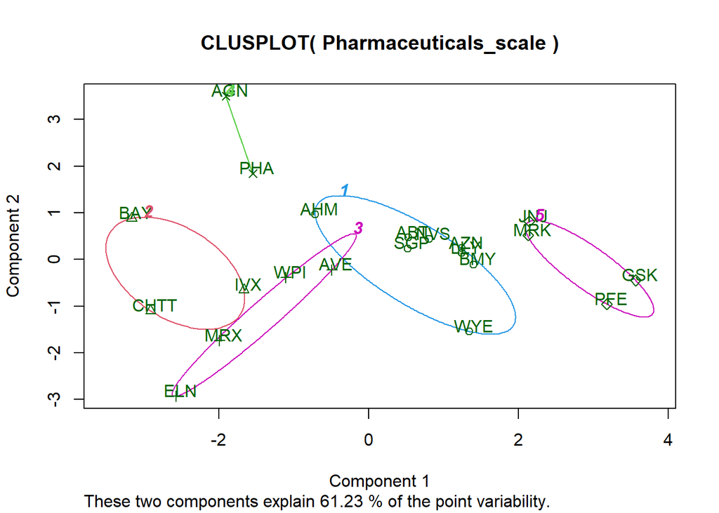

```r
clusplot(Pharmaceuticals_scale,final_Cluster$cluster, color = TRUE, labels = 2,lines = 0)
```

#B Interpret the clusters with respect to the numerical variables used in forming the clusters. #Cluster 1 - AHM,SGP,WYE,BMY,AZN, ABT, NVS, LLY ( lowest Market_Cap,lowest Beta,lowest PE_Ratio,highest Leverage,highest Rev_Growth.) #Cluster 2 - BAY, CHTT, IVX (lowest Rev_Growth,highest Beta and levearge,lowest Net_Profit_Margin) #Cluster 3 - WPI, MRX,ELN,AVE (lowest PE_Ratio,highest ROE,lowest ROA,lowest Net_Profit_Margin, highest Rev_Growth) #Cluster 4 - AGN, PHA (lowest Beta,lowest Asset_Turnover, Highest PE Ratio) #Cluster 5 - JNJ, MRK, PFE,GSK (Highest Market_Cap,ROE, ROA,Asset_Turnover Ratio and lowest Beta/PE Ratio)

```r
Pharmaceuticals_Cluster <- Pharmaceuticals[,c(12,13,14)]%>% mutate(clusters = final_Cluster$cluster)%>% arrange(clusters, ascending = TRUE)
Pharmaceuticals_Cluster
```

```
##      Median_Recommendation    Location Exchange clusters
## ABT           Moderate Buy          US     NYSE        1
## AHM             Strong Buy          UK     NYSE        1
## AZN          Moderate Sell          UK     NYSE        1
## BMY          Moderate Sell          US     NYSE        1
## LLY                   Hold          US     NYSE        1
## NVS                   Hold SWITZERLAND     NYSE        1
## SGP                   Hold          US     NYSE        1
## WYE                   Hold          US     NYSE        1
## BAY                   Hold     GERMANY     NYSE        2
## CHTT          Moderate Buy          US   NASDAQ        2
## IVX                   Hold          US     AMEX        2
## AVE           Moderate Buy      FRANCE     NYSE        3
## ELN          Moderate Sell     IRELAND     NYSE        3
## MRX           Moderate Buy          US     NYSE        3
## WPI          Moderate Sell          US     NYSE        3
## AGN           Moderate Buy      CANADA     NYSE        4
## PHA                   Hold          US     NYSE        4
## GSK                   Hold          UK     NYSE        5
## JNJ           Moderate Buy          US     NYSE        5
## MRK                   Hold          US     NYSE        5
## PFE           Moderate Buy          US     NYSE        5
```

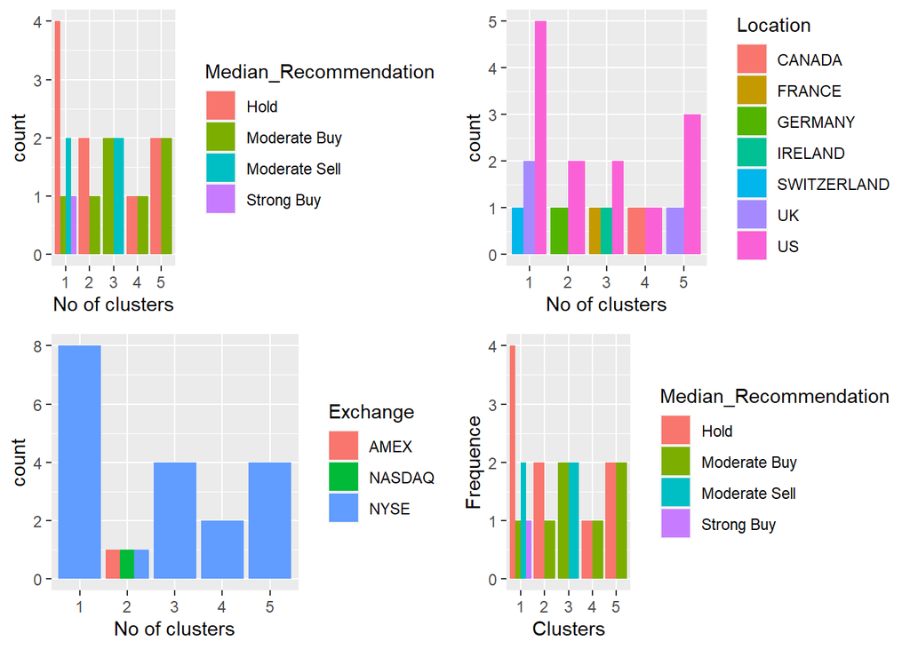

```r
plot1<-ggplot(Pharmaceuticals_Cluster, mapping = aes(factor(clusters), fill=Median_Recommendation))+geom_bar(position = 'dodge')+labs(x ='No of clusters')
plot2<- ggplot(Pharmaceuticals_Cluster, mapping = aes(factor(clusters),fill = Location))+geom_bar(position = 'dodge')+labs(x ='No of clusters')
plot3<- ggplot(Pharmaceuticals_Cluster, mapping = aes(factor(clusters),fill = Exchange))+geom_bar(position = 'dodge')+labs(x ='No of clusters')
plot4<- ggplot(Pharmaceuticals_Cluster, mapping = aes(factor(clusters), fill=Median_Recommendation)) + geom_bar(position = 'dodge') + labs(x='Clusters', y='Frequence')
grid.arrange(plot1, plot2, plot3,plot4)
```

#AS per the graph

#Cluster 1 :The Hold median is the highest in this cluster , which also contains separate Hold, Moderate Buy, Moderate Sell, and Strong Buy medians. They are listed on the NYSE and come from the US, UK, and Switzerland.

#Cluster 2: Although the firms are evenly divided throughout AMEX, NASDAQ, and NYSE, has a distinct Hold and Moderate Buy median, as well as a different count between the US and Germany.

#Cluster 3: listed on the NYSE, has separate counts for France, Ireland, and the US, and has equal moderate buy and sell medians.